# Appendix 0 Data Curation

Eslava, Ada

21 Nov 2021

###**Dataset description:**

This dataset represents the biodiversity of freshwater fish assemblages along the Trans‐Mexican Volcanic Belt, in Central Mexico. This region is the main area of distribution of the Goodeidae, a freshwater fish family endemic of Mexico.

The dataset contains fish incidence (i.e. presence/absence) data from two time periods: historical - prior to 1989 - and contemporary - year 2005- for a total of 53 sites. These sites represent locations where species in the Goodeidae family have been present in either one or both time periods.

Historical period: catalog data records of fish incidence were compiled from the collection of the Zoology Museum of the University of Michigan. The compiled fish incidence reports span over a century. The catalog records were completed using information on fish distributions available in the book: Freshwater Fishes of México (Miller, 2005), and local knowledge of the authors (Gesundheit and Mac??as Garcia, 2018).

Contemporary period (i.e 2005 survey): The aim of this survey was to obtain a complete inventory of all fish present in each sampling location. Sampling took place always during daylight hours and in 13 different trips over the course of the year 2005. The sampling techniques used included seining (4m2 seine net, 4mm mesh size), trapping (40‐cm‐long minnow traps, 5‐mm mesh size), and setting a gill net (20‐m2 gill net, mesh sizes of 1.3, 5.7, 7.6, and 8.9 cm). These methods were combined in order to sample fish of different sizes and living in different microhabitats. Sampling effort was adapted to the area and characteristics of each site. For more information, see Gesundheit and Mac??as Garcia (2018).

Gesundheit, P, Mac??as Garcia, C. The role of introduced species in the decline of a highly endemic fish fauna in Central Mexico. Aquatic Conserv: Mar Freshw Ecosyst. 2018; 28: 1384– 1395. https://doi.org/10.1002/aqc.2927

Comments: Efforts were made to achieve the most comprehensive depiction possible of the incidence of freshwater fish species in the surveyed sites in both the historical and the contemporary periods.

- There are a few things to consider:
  - Possible underrepresentation of some species that are nocturnal (i.e. assemblages were surveyed only during daylight).
  - Possible underrepresentation of a few species that are known to be better sampled with electrofishing, a method that could not be used in these locations. These species are Agonostomus monticola, Sicydium multipunctatum, Ictalurus dugesii, and Ictalurus mexicanus.
  - Possible influence of the sampling season on the probability to find certain fish species.

#### **Libraries:**

```r
library(dplyr)
library(tidyverse)
library(ggplot2)
library(rworldmap)
library(readxl)
library(stringdist)
library(hablar)
library(sp)
library(rgeos)
library(GeoRange)
library(kableExtra)
library(fishtree)
library(stringi)
library(data.table)
```

#### **Read data:**

```r
rm(list=ls())
locs <- read.csv2("locs_georeferidas.csv", h=T)               # Coordinates data sheet
dtUP <- read_excel("TODO_peces agosto 2010_PGM_Comments.xlsx") # Most up to date data file (Nov 2021)
```

#### **Data formatting:**

Check the structure of the data files.

```r
# Locs:
dim(locs)
sum(locs$Localidad=="")
locs <- locs[!locs$Localidad=="",]

# Data:
dim(dtUP)
sum(dtUP$Localidad=="")
sum(is.na(dtUP$Localidad))
dtUP <- dtUP[!is.na(dtUP$Localidad),]
head(dtUP, 2L)

# Modify some names with special characters:
names(dtUP) <- sapply(names(dtUP), function(x) stri_trans_general(x, id = "Latin-ASCII")) # Remove Spanish language accents

names(dtUP)[names(dtUP)=="Cuenta...9"] <- "CountHistNatCatalog"        # Native sps count Historical Catalog Records
names(dtUP)[names(dtUP)=="Cuenta...11"] <- "CountHistNatBroad"         # Native sps count Historical Broad Sense (Reconstruction)
names(dtUP)[names(dtUP)=="ampliado - catalogo"] <- "AddedHistNat(B-C)" # Difference sps count Broad Sense - Catalog
names(dtUP)[names(dtUP)=="Cuenta...17"] <- "CountNat2005"              # Native sps count 2005
names(dtUP)[names(dtUP)=="Cuenta...22"] <- "CountNonNat2005"           # Non-native sps count 2005
names(dtUP) <- gsub(" ", "", names(dtUP), fixed = TRUE)
dtUP <- as.data.frame(dtUP)
class(dtUP)
```

In order to assign the coordinate pairs to each locality, the name of each site in the “locs” and “dtUP” files must match.

```r
ClosestMatch = function(string, stringVector){
  stringVector[amatch(string, stringVector, maxDist=Inf)]
} # Function for approximate string matching

# Check there is correct matching of locality names between data frames:
MatchLoc <- ClosestMatch(dtUP$Localidad, locs$Localidad)
matches <- data.frame(dtUP$Localidad, MatchLoc)

# Flag mismatches in locality names:
matches$Flags <- rep(NA, nrow(matches))
vec <- c(1,4,10,12,13,15,17,20,22,25,29,30,32,35,45,47,55,57,60,62,71,79,82)
matches$Flags <- ifelse(rownames(matches) %in% vec, 1 ,matches$Flags)
sum(matches$Flags==1, na.rm=TRUE)
```

```
## [1] 23
```

```r
matchesII <- subset(matches, matches$Flags==1)

# Assign correct locality names to allow data merging:
locs$LocalidadII <- locs$Localidad
locs$LocalidadII <- plyr::revalue(locs$LocalidadII,
                                  c("Arroyo El Conejo en Rancho El Conejo"="arroyo El Conejo",
                                    "Rio La Eca en La Eca"="rio La Eca",
                                    "Rio Coscomate en Jilotepec"="rio Coscomate",
                                    "Rio Hidalgo en Ex-Hacienda El Porvenir"="canales en El Porvenir",
                                    "Rio Tilostoc en El Salitre"= "rio Tilostoc",
                                    "Rio Yautepec en Yautepec"="rio Yautepec",
                                    "Rio Nexapa en La Galarza"="rio Nexapa",
                                    "Arroyo en Teotihuacan"="Teotihuacan",
                                    "Canales de Xochimilco cerca del embarcadero Caltongo"="canales de Xochimilco",
                                    "Lago de Cuitzeo en La Palma"="lago de Cuitzeo",
                                    "Laguna de Zacapu en Zacapu"="lago de Zacapu",
"Lago de Patzcuaro en Puacuaro"="lago de Patzcuaro",
"Lago de Zirahuen en Aguaverde"="lago de Zirahuen",
"Laguna El Barril en El Barril"="laguna El Barril",
"Arroyo Grande en el Rancho Los Murillos"="rio Ameca en Los Murillos",
"manantial/balneario en Teuchitlan"="manantial/balneario El Rincon",
                                    "Rio Santa Ma. en Santa Ma. Del Rio"="rio Sta Maria",
"Manantiales de La Media Luna"="laguna de La Media Luna",
                                    "Rio Ayuquila en Corcovado"="rio Ayuquila",
                                    "Rio de Comala en Comala"="rio de Comala",
"Rio Cuarenta en Paso de Cuarenta"="rio Cuarenta",
                                    "manantial en Tocumbo" ="manantial/balneario en Tocumbo",
                                    "tributario del Rio Tuxpan"="trib. rio Tuxpan"))

MatchLoc <- ClosestMatch(dtUP$Localidad, locs$LocalidadII)
new_matches <- data.frame(dtUP$Localidad, MatchLoc)

# Some more names to re-type in order to allow matching:
locs$LocalidadII <- plyr::revalue(locs$LocalidadII, c("tributario del Rio Tamazula"="trib. rio Tamazula", "presa en Los Vergeles"="Los Vergeles"))
MatchLoc <- ClosestMatch(dtUP$Localidad, locs$LocalidadII)
new_matches <- data.frame(dtUP$Localidad, MatchLoc) # OK
```

Create a final dataframe and add all biological information.

Translate variable names into English.

```r
NDT <- data.frame(matrix(ncol = 8, nrow = 83))
NDT[,1] <- dtUP$SALIDA                                                           # Trip (survey 2005)
NDT[,2] <- str_split_fixed(dtUP$MES,"-",3)[,2]                                   # Month (survey 2005)
NDT[,3] <- rep(2005,nrow(NDT))                                                   # Year (2005)
NDT[,4] <- dtUP$Localidad                                                        # Site name I
NDT[,5] <- dtUP$Cuenca                                                           # Basin
NDT[,6] <- locs$Localidad[amatch(dtUP$Localidad, locs$LocalidadII, maxDist=Inf)] # Site name II
NDT[,7] <- locs$Latitud[locs$Localidad %in% NDT$X6]                              # Latitude
NDT[,8] <- locs$Longitud[locs$Localidad %in% NDT$X6]                             # Longitude

rownames(NDT) <- 1:nrow(NDT)

identical(dtUP$Localidad, NDT$X4) #TRUE, same order
NDT <- data.frame(NDT, dtUP[,5:26])
names(NDT) <- c("Trip", "Month", "Year", "SiteName", "DrainageBasin", "SiteNameII", "Latitude", "Longitude", names(dtUP[,5:26]))

names(NDT) <- plyr::revalue(names(NDT),c("NativosEsperadossegunno.decatalogo"="HistoricalNatCatalog","NativosEsperadosampliado"="HistoricalNatBroad","ExoticosEsperadosNEODAT"="HistoricalExotics","fechadecolecta"="DateCollected","no.decolectas"="NumberCollections",
"nativosnoesperados?"="NonExpectedNat?","nativosnoesperados"="NonExpectedNat","mismasriquezas"="SameRichness","ExoticosEncontrados"="ExoticsFound2005","Datosanecdoticos"="Anectodic", "ExtintosoExtirpadosenlaLocalidad"="Extint/ExtirpatedInLoc","Notas"="Comments",
"NativosEncontrados2005"="NativeFound2005","enc/esp"="RatioFound/Expected"))

NDT <- NDT %>% retype()
str(NDT)
```

Create a column that contains information on the type of water body (using SM of Gesundheit and Macias Garcia, 2018)

```r
NDT$SiteType <- rep(NA, nrow(NDT))
NDT$SiteName <- stri_trans_general(NDT$SiteName, id = "Latin-ASCII") # Remove accents

# Streams:
NDT$SiteType <- ifelse(NDT$DrainageBasin %in% c("El Salado", "rio Cuitzmala",
                                                "rio Purificacion",
                                                "rio Cihuatlan",
                                                "lagunas de Sayula"), "Stream", NDT$SiteType) # All sites in these basins are streams
NDT$SiteType <- ifelse(NDT$SiteName %in% c("rio El Mimbre", "rio Tunal", "rio Sta Maria",
                                           "rio Barranquitas", "rio Yautepec",
                                           "trib. rio Tamazula", "trib. rio Tuxpan",
                                           "rio de Comala", "arroyo La Yerbabuena",
                                           "rio Coscomate", # Assumed
                                           "rio Turbio cerca de El Nopal", "rio Tilostoc",
                                           "rio Lerma cerca de Solis", "trib. del rio 'San Pedro'"), "Stream", NDT$SiteType)

# trib. del rio 'San Pedro' is the same as Tributary to Ayuquila River N of Cofradia de Duendes.
# Correct to the second name as it is more precise:
NDT$SiteName[NDT$SiteName=="trib. del rio 'San Pedro'"] <- "trib. Ayuquila River N of Cofradia de Duendes"

# Impounded streams:
NDT$SiteType <- ifelse(NDT$SiteName %in% c("represa en Hda. San Sebastian",
                                           "arroyo Los Pajaritos"), "Impounded stream", NDT$SiteType)

# Springs:
NDT$SiteType <- ifelse(NDT$SiteName %in% c("manantial en El Toboso", "manantial en 27 de Nov.",
                                           "manantial en Los Berros", "manantial en Puerta del Rio",
                                           "manantial Molino de Chapultepec"), "Spring", NDT$SiteType)
# Small rivers:
NDT$SiteType <- ifelse(NDT$SiteName %in% c("rio 'San Pedro' en Belen del Refugio",
                                           "rio Gde. de Santiago en Ocotlan",
                                           "rio Salado",
                                           "rio Ayutla",
                                           "rio Ameca en La Vega",
                                           "rio Ameca en Los Murillos",
                                           "rio de La Pola",
                                           "rio de La Laja en Atotonilco",
                                           "rio Lerma en Puerto del Valle",
                                           "rio Ayuquila",
                                           "rio Nexapa"), "Small river", NDT$SiteType)
# Shallow lakes:
NDT$SiteType <- ifelse(NDT$SiteName %in% c("lago de Zumpango",
                                           "lago de Chalco",
                                           "Laguna Zempoala",
                                           "lago de Yuriria",
                                           "laguna de Magdalena",
                                           "laguna La Colorada",
                                           "laguna de Sta Maria",
                                           "lago de Zacapu",
                                           "lago de Cuitzeo",
                                           "lago de Patzcuaro",
                                           "lago de Chapala en Mezcala"), "Shallow lake", NDT$SiteType)

# Reservoirs:
NDT$SiteType <- ifelse(NDT$SiteName %in% c("P. Ignacio Ramirez", "P. San Juanico", "P. Cointzio"), "Reservoir", NDT$SiteType)

# Lakes:
NDT$SiteType <- ifelse(NDT$SiteName %in% c("lago de Zirahuen"), "Lake", NDT$SiteType)

# Canals:
NDT$SiteType <- ifelse(NDT$SiteName %in% c("canales de Xochimilco"),
                       "Open canals shallow lake", NDT$SiteType)
NDT$SiteType <- ifelse(NDT$SiteName %in% c("canales en Zinzimeo", "canales en El Porvenir"),
                       "Irrigation canals", NDT$SiteType)

# Springs forming small shallow lake:
NDT$SiteType <- ifelse(NDT$SiteName %in% c("laguna de La Minzita", "laguna de La Media Luna"),
                       "Springs forming small shallow lake", NDT$SiteType)

# Impounded outflow of a system of springs
NDT$SiteType <- ifelse(NDT$SiteName %in% c("P. de Sta Catarina"),
                       "Impounded outflow system of springs", NDT$SiteType)
# Modified springs:
NDT$SiteType <- ifelse(NDT$SiteName %in% c("balneario Los Rosales",
                                           "manantial/balneario en Tocumbo",
                                           "manantial/balneario El Rincon"),
                       "Modified spring", NDT$SiteType)

# Not habitable:
NDT$SiteType <- ifelse(NDT$SiteName %in% c("Texcoco 1", "Texcoco 2", "Teotihuacan",
                                           "manantial en Cerro Gordo",
                                           "manantial El Sacristan",
                                           "trib. del rio Lerma en Tanhuato",
                                           "rio Gde. de Santiago en Poncitlan",
                                           "presa El Gigante",
                                           "rio Turbio cerca de Manuel Doblado",
                                           "rio Turbio cerca de Cueramaro",
                                           "rio Turbio en San Juan de la Puerta"), "Not habitable",NDT$SiteType) # These include localities that have ceased to exist, that were found dry or with foul water.

sum(is.na(NDT$SiteType)) # OK
# NA: rio en 6 de Enero.
# NA: presa sobre el rio Carrizal
# NA: rio Cuarenta (considerada un outlier por Pablo & Tino)
# NA: Los Vergeles
```

- Revise temporal and spatial data:
  - Data were collected in multiple fieldwork trips during 2005 except for May and August (Gesundheit and Mac??as Garcia, 2018)
  - Coordinates fall in the correct geographic area.

```r
# Temporal:
sort(unique(NDT$Month))
sort(unique(NDT$Year))

# Spatial:
world <- getMap(resolution = "low")
Mexmap <- "Mexico"
Mex <- world[world@data$ADMIN %in% "Mexico", ]

range(NDT$Longitude) # Rio Barraquitas missing (-)
NDT$Longitude[NDT$SiteName=="rio Barranquitas"] <- NDT$Longitude[NDT$SiteName=="rio Barranquitas"]*(-1)

range(NDT$Latitude)  # 18.51 24.62
range(NDT$Longitude) # -104.90  -98.45
```

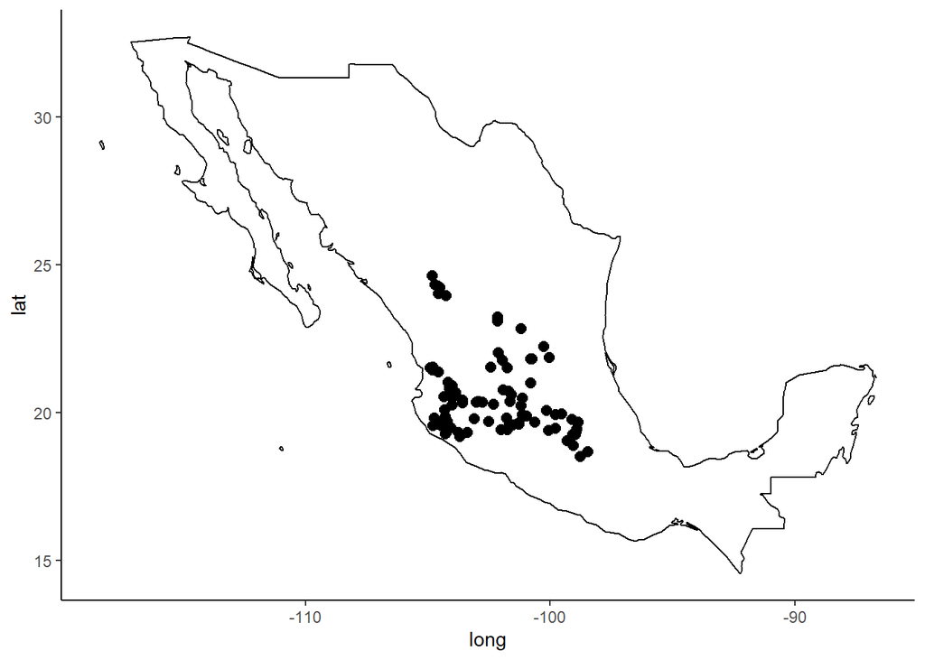

```r
(Mmap <- ggplot() +
    geom_polygon(data = Mex,
                 aes(x = long, y = lat, group = group),
                 fill = NA, colour = "black") +
    geom_point(data = NDT,
               aes(x = Longitude, y = Latitude), size=2.5)+
  theme_classic())
```

- Remove a couple dubious sps observations in the historical assemblage according to data collectors.
  - ?Z. quitzeoensis?) in “manantial Molino de Chapultepec”
  - A. regalis (?) in “manantial/balneario en Tocumbo”
- Add a few species observations:
  - Gambusia senilis considered native in “manantial en 27 de noviembre” despite the records from the historical collectors Humphries y Smith. Miller mentions similar populations possibly of G senilis in the area and, in 2005, the sps was found in two close reservoirs, so it was considered more likely that the species was native and not translocated in this locality.
  - Herichthys cf cyanoguttatus was found in “el manantial en Puerta del Rio” and was considered an introduced species. According to Miller, the sps has been translocated but there are also populations with undetermined taxonomic status. Due to the uncertainty with this one record we removed it from the dataset, also following (Gesundheit and Macias Garcia, 2018).

```r
# HistoricalNatCatalog:
NDT$HistoricalNatCatalog[NDT$SiteName=="manantial/balneario en Tocumbo"] <- "C. pardalis" # String without A.regalis

# HistoricalNatBroad:
NDT$HistoricalNatBroad[NDT$SiteName=="manantial Molino de Chapultepec"] <- "A. diazi, G. atripinnis, S. lermae, A. dugesii, (A. robustus?, X. variata" # String without Z. quitzeoensis
NDT$HistoricalNatBroad[NDT$SiteName=="manantial/balneario en Tocumbo"] <- "G. atripinnis, C. pardalis" # String without A.regalis

# Check G. cf. senilis (manantial en 27 de noviembre):
NDT$HistoricalNatCatalog[NDT$SiteName=="manantial en 27 de Nov."]
```

```
## [1] "C. lateralis, C. meeki, G. cf. senilis (como exotico), M. mezquital"
```

```r
NDT$HistoricalNatBroad[NDT$SiteName=="manantial en 27 de Nov."]
```

```
## [1] "C. lateralis, C. meeki, G. cf. senilis, M. mezquital"
```

```r
NDT$HistoricalExotics[NDT$SiteName=="manantial en 27 de Nov."]
```

```
## [1] "L. macrochirus"
```

```r
# Remove "Herichthys cf cyanoguttatus":
NDT$ExoticsFound2005[NDT$SiteName=="manantial en Puerta del Rio"]
```

```
## [1] "H. cf. cyanoguttatus, Oreochromis sp., P. mexicana"
```

```r
NDT$ExoticsFound2005[NDT$SiteName=="manantial en Puerta del Rio"] <- "Oreochromis sp., P. mexicana"
```

Translate site & basin Spanish names according to Gesundheit & Macias-Garcia (2018):

```r
sort(unique(NDT$DrainageBasin))
```

```
##  [1] "alto Lerma"               "bajo Lerma"
##  [3] "de Mexico"                "El Salado"
##  [5] "lago de Cuitzeo"          "lago de Patzcuaro"
##  [7] "lago de Yuriria"          "lago de Zirahuen"
##  [9] "lagunas de Sayula"        "medio Lerma"
## [11] "rio Ameca"                "rio Armeria"
## [13] "rio Balsas"               "rio Cihuatlan"
## [15] "rio Cuitzmala"            "rio Gde. de Santiago"
## [17] "rio Naranjo - Coahuayana" "rio Panuco"
## [19] "rio Purificacion"         "rio San Pedro Mezquital"
```

```r
NDT$DrainageBasinE <- NA
NDT$SiteNameE <- NA

NDT$DrainageBasinE <- plyr::revalue(NDT$DrainageBasin, c("alto Lerma"="Upper Lerma",
                                                        "de Mexico"="Valley of Mexico",
                                                        "El Salado"="El Salado",
                                                        "lago de Cuitzeo"="Lake Cuitzeo",
                                                        "lago de Patzcuaro"="Lake Patzcuaro",
                                                        "lago de Yuriria"="Lake Yuriria",
                                                        "lagunas de Sayula"="Sayula lagoons",
                                                        "medio Lerma"="Middle Lerma",
                                                        "rio Ameca"="Ameca River",
                                                        "rio Armeria"="Armeria River",
                                                        "rio Balsas"="Balsas River",
                                                        "rio Cihuatlan"="Cihuatlan River",
                                                        "rio Cuitzmala"="Cuitzmala River",
                                                        "rio Gde. de Santiago"="Grande de Santiago",
                                                        "rio Naranjo - Coahuayana"="Coahuayana River",
                                                        "rio Panuco"="Panuco River",
                                                        "rio Purificacion"="Purificacion River",
                                                        "rio San Pedro Mezquital"="San Pedro Mezquital", "bajo Lerma"="Lower Lerma", "lago de Zirahuen"="Lake Zirahuen"))
sort(unique(NDT$DrainageBasinE))
```

```
##  [1] "Ameca River"         "Armeria River"       "Balsas River"
##  [4] "Cihuatlan River"     "Coahuayana River"    "Cuitzmala River"
##  [7] "El Salado"           "Grande de Santiago"  "Lake Cuitzeo"
## [10] "Lake Patzcuaro"      "Lake Yuriria"        "Lake Zirahuen"
## [13] "Lower Lerma"         "Middle Lerma"        "Panuco River"
## [16] "Purificacion River"  "San Pedro Mezquital" "Sayula lagoons"
## [19] "Upper Lerma"         "Valley of Mexico"
```

```r
sort(unique(NDT$SiteName))
```

```
##  [1] "arroyo El Conejo"
##  [2] "arroyo en Acatlan"
##  [3] "arroyo en Agua de Enmedio"
##  [4] "arroyo La Yerbabuena"
##  [5] "arroyo Los Pajaritos"
##  [6] "balneario Los Rosales"
##  [7] "canales de Xochimilco"
##  [8] "canales en El Porvenir"
##  [9] "canales en Zinzimeo"
## [10] "lago de Chalco"
## [11] "lago de Chapala en Mezcala"
## [12] "lago de Cuitzeo"
## [13] "lago de Patzcuaro"
## [14] "lago de Yuriria"
## [15] "lago de Zacapu"
```

[output cut: 68 more lines]

```r
NDT$SiteNameE <- plyr::revalue(NDT$SiteName, c("arroyo El Conejo"="El Conejo Stream",
                                               "arroyo en Acatlan"="Stream at Acatlan de Juarez",
                                               "arroyo en Agua de Enmedio"="Stream at Agua de Enmedio",
                                               "arroyo La Yerbabuena"="La Yerbabuena Stream",
                                               "arroyo Los Pajaritos"="Los Pajaritos Stream",
                                               "balneario Los Rosales"="Balneario Los Rosales",
                                               "canales de Xochimilco"="Xochimilco Canals",
                                               "canales en Zinzimeo"="Zinzimeo Canals",
                                               "lago de Chalco"="Lake Chalco",
                                               "lago de Yuriria"="Lake Yuriria",
                                               "lago de Zacapu"="Zacapu Lake",
                                               "lago de Zumpango"="Zumpango Lake",
                                               "laguna de La Minzita"="La Minzita Lagoon",
                                               "laguna de Magdalena"="Magdalena Lagoon",
                                               "laguna de Sta Maria"="Sta Maria Lagoon",
                                               "laguna La Colorada"="La Colorada Lagoon",
                                               "Laguna Zempoala"="Zempoala Lagoon",
                                               "manantial en 27 de Nov."="Spring at 27 de Noviembre",
                                               "manantial en El Toboso"="Spring at El Toboso",
                                               "manantial en Los Berros"="Spring at Los Berros",
                                               "manantial en Puerta del Rio"="Spring at Puerta del Rio",
                                               "manantial Molino de Chapultepec"="Spring outside of Molino de Chapultepec",
                                               "manantial/balneario en Tocumbo"="Spring at Tocumbo",
                                               "P. de Sta Catarina"="Santa Catarina Reservoir",
                                               "P. Ignacio Ramirez"="Ignacio Ramirez Reservoir",
                                               "represa en Hda. San Sebastian"="Impoundment San Sebastian",
                                               "rio 'San Pedro' en Belen del Refugio"="San Pedro River at Belen del Refugio",
                                               "rio Amborin"="Amborin River",
                                               "rio Ameca en La Vega"="Ameca River at La Vega",
                                               "rio Ameca en Los Murillos"="Ameca River at Los Murillos",
                                               "rio Ayuquila"="Ayuquila River",
                                               "rio Ayutla"="Ayutla River",
                                               "rio Barranquitas"="Barraquitas River",
                                               "rio de Comala"="De Comala River",
                                               "rio de La Laja en Atotonilco"="De La Laja en Atotonilco River",
                                               "rio de La Pola"="De La Pola River",
                                               "rio El Huizcolote"="El Huizcolote River",
                                               "rio El Mimbre"="El Mimbre River",
                                               "rio Gde. de Santiago en Ocotlan"="Gde. de Santiago River at Ocotlan",
                                               "rio Higuerilla"="Higuerilla River",
                                               "rio La Eca"="La Eca River",
                                               "rio Lerma cerca de Solis"="Lerma River close to Solis",
                                               "rio Lerma en Puerto del Valle"="Lerma River at Puerto del Valle",
                                               "rio Minatitlan en La Loma"="Minatitlan River at La Loma",
                                               "rio Salado"="Salado River",
                                               "rio Sta Maria"="Sta Maria River",
                                               "rio Tilostoc"="Tilostoc River",
                                               "rio Tunal"="Tunal River",
                                               "rio Turbio cerca de El Nopal"="Turbio River close to El Nopal",
                                               "rio Yautepec"="Yautepec River",
                                               "trib. Ayuquila River N of Cofradia de Duendes"="Tributary to Ayuquila River",
                                               "trib. rio Tamazula"="Tributary to Tamazula River",
                                               "trib. rio Tuxpan"="Tributary to Tuxpan River",
                                               "canales en El Porvenir"="Canals at El Porvenir", "lago de Chapala en Mezcala"="Lake Chapala at Mezcala", "lago de Cuitzeo"="Lake Cuitzeo", "lago de Patzcuaro"="Patzcuaro Lake", "lago de Zirahuen"="Zirahuen Lake","laguna de La Media Luna"="La Media Luna Lagoon", "laguna de San Marcos"="San Marcos Lagoon", "laguna El Barril"="El Barril Lagoon", "manantial cerca de Illescas"="Unnamed spring outside Illescas", "manantial El Sacristan"="El Sacristan Spring", "manantial en Cerro Gordo"="Unnamed spring at Cerro Gordo", "presa El Gigante"="El Gigante Reservoir", "presa sobre el rio Carrizal"="Reservoir above the Carrizal River", "rio Coscomate"="Coscomate River", "rio Cuarenta"="Cuarenta River", "rio en 6 de Enero"="River at 6 de Enero", "rio Gde. de Santiago en Poncitlan"="Grande de Santiago River at Poncitlan", "rio Marabasco"="Marabasco River", "rio Nexapa"="Nexapa River", "rio Turbio cerca de Cueramaro"="Turbio River E of Cueramaro","rio Turbio cerca de Manuel Doblado"="Turbio River NE of Manuel Doblado", "rio Turbio en San Juan de la Puerta"="Turbio River at San Juan de La Puerta", "trib. del rio Lerma en Tanhuato"="Tributary to Lerma River at Tanhuato", "manantial/balneario El Rincon"="Manantial/balneario El Rincon"))
sort(unique(NDT$SiteNameE))
```

```
##  [1] "Amborin River"
##  [2] "Ameca River at La Vega"
##  [3] "Ameca River at Los Murillos"
##  [4] "Ayuquila River"
##  [5] "Ayutla River"
##  [6] "Balneario Los Rosales"
##  [7] "Barraquitas River"
##  [8] "Canals at El Porvenir"
##  [9] "Coscomate River"
## [10] "Cuarenta River"
## [11] "De Comala River"
## [12] "De La Laja en Atotonilco River"
## [13] "De La Pola River"
## [14] "El Barril Lagoon"
## [15] "El Conejo Stream"
```

[output cut: 68 more lines]

```r
save(NDT, file="NDT.RData")
write.csv2(NDT, file="NDT.csv")
```

#### **Taxonomic updates**

Taxonomic updates are made using the list of freshwater fishes from Mexico in FishBase (Froese & Pauly, 2022), Freshwater Fishes of México (Miller, 2005) and the Global Biodiversity Information Facility (GBIF).

[output not shown]

[output cut: 120 more lines]

List of species:

Short2

Genus_species

Update1

Update2

Source1

Source2

Final

NA

NA

NA

NA

NA

NA

(?)

NA

NA

NA

NA

NA

NA

?

NA

NA

NA

NA

NA

NA

A . dugesii

A dugesii

Allotoca dugesii

NA

NA

NA

NA

NA

A. ‘fasciatus’

A fasciatus

Astyanax fasciatus

Astyanax mexicanus

NA

Miller (2005)

NA

NA

A. aeneus

A aeneus

Astyanax aeneus

NA

NA

NA

NA

NA

A. aeneus

A aeneus

Astyanax aeneus

NA

NA

NA

NA

NA

A. aphanea

A aphanea

Algansea aphanea

NA

NA

NA

NA

NA

A. balsana

A balsana

Atherinella balsana

NA

NA

NA

NA

NA

A. catarinae

A catarinae

Allotoca catarinae

NA

NA

NA

NA

NA

A. diazi

A diazi

Allotoca diazi

NA

NA

NA

NA

NA

A. dugesii

A dugesii

Allotoca dugesii

NA

NA

NA

NA

NA

A. dugesii

A dugesii

Allotoca dugesii

NA

NA

NA

NA

NA

A. goslinei

A goslinei

Allotoca goslinei

NA

NA

NA

NA

NA

A. hubbsi

A hubbsi

Allodontichthys hubbsi

NA

NA

NA

NA

NA

A. hubbsi

A hubbsi

Allodontichthys hubbsi

NA

NA

NA

NA

NA

A. maculata

A maculata

Allotoca maculata

NA

NA

NA

NA

NA

A. meeki

A meeki

Allotoca meeki

NA

NA

NA

NA

NA

A. mexicanus

A mexicanus

Astyanax mexicanus

NA

NA

NA

NA

NA

A. monticola

A monticola

A monticola

NA

NA

NA

NA

NA

A. monticola

A monticola

A monticola

NA

NA

NA

NA

NA

A. nigrofasciatus

A nigrofasciatus

Archocentrus nigrofasciatus

Amatitlania nigrofasciata

NA

FishBase

NA

NA

A. polylepis

A polylepis

Allodontichthys polylepis

NA

NA

NA

NA

NA

A. polylepis

A polylepis

Allodontichthys polylepis

NA

NA

NA

NA

NA

A. popoche

A popoche

Algansea popoche

NA

NA

NA

NA

NA

A. robustus

A robustus

Alloophorus robustus

NA

NA

NA

NA

NA

A. robustus

A robustus

Alloophorus robustus

NA

NA

NA

NA

NA

(A. robustus?

A robustus

Alloophorus robustus

NA

NA

NA

NA

NA

A. sallaei

A sallaei

Aztecula sallaei

NA

NA

NA

NA

NA

A. sallaei

A sallaei

Aztecula sallaei

NA

NA

NA

NA

NA

A. splendens

A splendens

Ameca splendens

NA

NA

NA

NA

NA

A. tamazulae

A tamazulae

Allodontichthys tamazulae

NA

NA

NA

NA

NA

A. tamazulae

A tamazulae

Allodontichthys tamazulae

NA

NA

NA

NA

NA

A. tincella

A tincella

Algansea tincella

NA

NA

NA

NA

NA

A. tincella

A tincella

Algansea tincella

NA

NA

NA

NA

NA

A. tincella

A tincella

Algansea tincella

NA

NA

NA

NA

NA

A. toweri

A toweri

Ataeniobius toweri

NA

NA

NA

NA

NA

A. zacapuensis

A zacapuensis

Allotoca zacapuensis

NA

NA

NA

NA

NA

A. zonistius

A zonistius

Allodontichthys zonistius

NA

NA

NA

NA

NA

A. zonistius

A zonistius

Allodontichthys zonistius

NA

NA

NA

NA

NA

Astyanax sp.

Astyanax sp

Astyanax sp

NA

NA

NA

NA

NA

‘C’. bartoni

C bartoni

Cichlasoma bartoni

Nosferatu bartoni

NA

FishBase

NA

NA

‘C’. labridens

C labridens

Cichlasoma labridens

Nosferatu labridens

NA

FishBase

NA

NA

C. audax

C audax

Characodon audax

NA

NA

NA

NA

NA

C. auratus

C auratus

Carassius auratus

NA

NA

NA

NA

NA

C. bartoni

C bartoni

Cichlasoma bartoni

Nosferatu bartoni

NA

FishBase

NA

NA

C. beani

C beani

Cichlasoma beani

Mayaheros beani

NA

FishBase

NA

NA

C. beani

C beani

Cichlasoma beani

Mayaheros beani

NA

FishBase

NA

NA

C. carpio

C carpio

Cyprinus carpio

NA

NA

NA

NA

NA

C. carpio

C carpio

Cyprinus carpio

NA

NA

NA

NA

NA

C. carpio (sin georreferencia)

C carpio sin georreferencia

Cyprinus carpio

NA

NA

NA

NA

NA

C. encaustus

C encaustus

Chapalichthys encaustus

NA

NA

NA

NA

NA

C. encaustus

C encaustus

Chapalichthys encaustus

NA

NA

NA

NA

NA

C. istlanum

C istlanum

Cichlasoma istlanum

NA

NA

NA

NA

NA

(C. istlanum

C istlanum

Cichlasoma istlanum

NA

NA

NA

NA

NA

C. istlanum

C istlanum

Cichlasoma istlanum

NA

NA

NA

NA

NA

C. labridens

C labridens

Cichlasoma labridens

Nosferatu labridens

NA

FishBase

NA

NA

C. lateralis

C lateralis

Characodon lateralis

NA

NA

NA

NA

NA

C. meeki

C meeki

Cyprinodon meeki

NA

NA

NA

NA

NA

C. pardalis

C pardalis

Chapalichthys pardalis

NA

NA

NA

NA

NA

C. pardalis

C pardalis

Chapalichthys pardalis

NA

NA

NA

NA

NA

C. tessellatus

C tessellatus

Cualac tessellatus

NA

NA

NA

NA

NA

confirmamos la presencia de Z. tequila y A. splendens

confirmamos la presencia de Z tequila y A splendens

Zoogoneticus tequila, Ameca splendens

NA

NA

NA

NA

NA

D. dichroma

D dichroma

Dionda dichroma

Tampichthys dichroma

NA

FishBase

NA

NA

D. mandibularis

D mandibularis

Dionda mandibularis

Tampichthys mandibularis

NA

FishBase

NA

NA

encontrada seca

encontrada seca

none

NA

NA

NA

NA

NA

es la localidad?

es la localidad

none

NA

NA

NA

NA

NA

G. affinis

G affinis

Gambusia affinis

NA

NA

NA

NA

NA

G. atripinnis

G atripinnis

Goodea atripinnis

NA

NA

NA

NA

NA

G. atripinnis

G atripinnis

Goodea atripinnis

NA

NA

NA

NA

NA

G. atripinnis

G atripinnis

Goodea atripinnis

NA

NA

NA

NA

NA

G. cf. senilis

G cf senilis

Gambusia cf senilis

NA

NA

NA

NA

NA

G. cf. senilis (como exotico)

G cf senilis como exotico

Gambusia cf senilis

NA

NA

NA

NA

NA

G. fluviatilis

G fluviatilis

Gobiesox fluviatilis

NA

NA

NA

NA

NA

G. multiradiatus

G multiradiatus

Girardinichthys multiradiatus

NA

NA

NA

NA

NA

G. multiradiatus

G multiradiatus

Girardinichthys multiradiatus

NA

NA

NA

NA

NA

(G. multiradiatus)

G multiradiatus

Girardinichthys multiradiatus

NA

NA

NA

NA

NA

G. viviparus

G viviparus

Girardinichthys viviparus

NA

NA

NA

NA

NA

G. viviparus

G viviparus

Girardinichthys viviparus

NA

NA

NA

NA

NA

G. yucatana

G yucatana

Gambusia yucatana

NA

NA

NA

NA

NA

Gila sp.

Gila sp

Gila sp

NA

NA

NA

NA

NA

H. bimaculata

H bimaculata

Heterandria bimaculata

Pseudoxiphophorus bimaculatus

NA

FishBase

NA

NA

H. bimaculata

H bimaculata

Heterandria bimaculata

Pseudoxiphophorus bimaculatus

NA

FishBase

NA

NA

H. boucardi

H boucardi

Hybopsis boucardi

Notropis boucardi

NA

FishBase

NA

NA

H. boucardi

H boucardi

Hybopsis boucardi

Notropis boucardi

NA

FishBase

NA

NA

H. burtoni

H burtoni

Haplochromis burtoni

Astatotilapia burtoni

NA

FishBase

NA

NA

H. calientis

H calientis

Hybopsis calientis

Notropis calientis

NA

FishBase

NA

NA

H. cf. cyanoguttatus

H cf cyanoguttatus

Herichthys cf cyanoguttatus

NA

NA

NA

NA

NA

H. cyanoguttatus

H cyanoguttatus

Herichthys cyanoguttatus

NA

NA

NA

NA

NA

H. jonesii

H jonesii

Heterandria jonesii

Pseudoxiphophorus jonesii

NA

FishBase

NA

NA

H. jonesii

H jonesii

Heterandria jonesii

Pseudoxiphophorus jonesii

NA

FishBase

NA

NA

H. turneri

H turneri

Hubbsina turneri

NA

NA

NA

NA

NA

Heterandria sp.

Heterandria sp

Heterandria sp

Pseudoxiphophorus sp

NA

FishBase

NA

NA

Heterandria sp.

Heterandria sp

Heterandria sp

Pseudoxiphophorus sp

NA

FishBase

NA

NA

I. dugesii

I dugesii

Ictalurus dugesii

NA

NA

NA

NA

NA

I. furcidens

I furcidens

Ilyodon furcidens

NA

NA

NA

NA

NA

I. furcidens

I furcidens

Ilyodon furcidens

NA

NA

NA

NA

NA

I. mexicanus

I mexicanus

Ictalurus mexicanus

NA

NA

NA

NA

NA

I. whitei

I whitei

Ilyodon whitei

NA

NA

NA

NA

NA

I. whitei

I whitei

Ilyodon whitei

NA

NA

NA

NA

NA

L. macrochirus

L macrochirus

Lepomis macrochirus

NA

NA

NA

NA

NA

L. macrochirus

L macrochirus

Lepomis macrochirus

NA

NA

NA

NA

NA

L. macrochirus (1965)

L macrochirus 1965

Lepomis macrochirus

NA

NA

NA

NA

NA

M. aculeata

M aculeata

Menidia aculeata

Chirostoma aculeatum

NA

FishBase

NA

NA

M. arge

M arge

Menidia arge

Chirostoma arge

NA

FishBase

NA

NA

M. attenuata

M attenuata

Menidia attenuata

Chirostoma attenuatum

NA

FishBase

NA

NA

M. attenuata

M attenuata

Menidia attenuata

Chirostoma attenuatum

NA

FishBase

NA

NA

M. chapalae

M chapalae

Menidia chapalae

Chirostoma chapalae

NA

FishBase

NA

NA

M. charari

M charari

Menidia charari

Chirostoma charari

NA

FishBase

NA

NA

M. consocia

M consocia

Menidia consocia

Chirostoma consocium

NA

FishBase

NA

NA

M. estor

M estor

Menidia estor

Chirostoma estor

NA

FishBase

NA

NA

M. humboldtiana

M humboldtiana

Menidia humboldtiana

Chirostoma humboldtianum

NA

FishBase

NA

NA

M. jordani

M jordani

Menidia jordani

Chirostoma jordani

NA

FishBase

NA

NA

M. jordani

M jordani

Menidia jordani

Chirostoma jordani

NA

FishBase

NA

NA

M. labarca

M labarca

Menidia labarcae

Chirostoma labarcae

NA

FishBase

NA

NA

M. mezquital

M mezquital

Menidia mezquital

Chirostoma jordani

NA

FishBase

NA

NA

M. patzcuaro

M patzcuaro

Menidia patzcuaro

Chirostoma patzcuaro

NA

FishBase

NA

NA

M. riojai

M riojai

Menidia riojai

Chirostoma riojai

NA

FishBase

NA

NA

M. riojai

M riojai

Menidia riojai

Chirostoma riojai

NA

FishBase

NA

NA

M. salmoides

M salmoides

Micropterus salmoides

NA

NA

NA

NA

NA

M. salmoides

M salmoides

Micropterus salmoides

NA

NA

NA

NA

NA

Menidia sp.

Menidia sp

Menidia sp

Chirostoma sp

NA

FishBase

NA

NA

N. amecae

N amecae

Notropis amecae

NA

NA

NA

NA

NA

nada

nada

none

NA

NA

NA

NA

NA

nada (localidad no propicia)

nada localidad no propicia

none

NA

NA

NA

NA

NA

ninguno

ninguno

none

NA

NA

NA

NA

NA

no era la localidad buscada

no era la localidad buscada

none

NA

NA

NA

NA

NA

no hay vida acuática

no hay vida acuatica

none

NA

NA

NA

NA

NA

O. aureus

O aureus

Oreochromis aureus

NA

NA

NA

NA

NA

O. aureus

O aureus

Oreochromis aureus

NA

NA

NA

NA

NA

O. aureus (sin georreferencia)

O aureus sin georreferencia

Oreochromis aureus

NA

NA

NA

NA

NA

O. mossambicus

O mossambicus

Oreochromis mossambicus

NA

NA

NA

NA

NA

O. niloticus

O niloticus

Oreochromis niloticus

NA

NA

NA

NA

NA

O. niloticus

O niloticus

Oreochromis niloticus

NA

NA

NA

NA

NA

observamos Oreochromis

observamos Oreochromis

Oreochromis sp

NA

NA

NA

NA

NA

Oreochromis sp.

Oreochromis sp

Oreochromis sp

NA

NA

NA

NA

NA

Oreochromis sp.

Oreochromis sp

Oreochromis sp

NA

NA

NA

NA

NA

P. ‘sphenops’

P sphenops

Poecilia sphenops

NA

NA

NA

NA

NA

P. baenschi

P baenschi

Poeciliopsis baenschi

NA

NA

NA

NA

NA

P. baenschi

P baenschi

Poeciliopsis baenschi

NA

NA

NA

NA

NA

P. balsas

P balsas

Poeciliopsis balsas

NA

NA

NA

NA

NA

P. balsas)

P balsas

Poeciliopsis balsas

NA

NA

NA

NA

NA

P. butleri

P butleri

Poecilia butleri

NA

NA

NA

NA

NA

P. butleri

P butleri

Poecilia butleri

NA

NA

NA

NA

NA

P. butleri (1968)

P butleri 1968

Poecilia butleri

NA

NA

NA

NA

NA

P. cf. butleri

P cf butleri

Poecilia cf butleri

NA

NA

NA

NA

NA

P. cf. sphenops

P cf sphenops

Poecilia cf sphenops

NA

NA

NA

NA

NA

P. chica

P chica

Poecilia chica

NA

NA

NA

NA

NA

P. gracilis

P gracilis

Poeciliopsis gracilis

NA

NA

NA

NA

NA

P. infans

P infans

Poeciliopsis infans

NA

NA

NA

NA

NA

P. infans

P infans

Poeciliopsis infans

NA

NA

NA

NA

NA

P. latipunctata

P latipunctata

Poecilia latipunctata

NA

NA

NA

NA

NA

P. mexicana

P mexicana

Poecilia mexicana

NA

NA

NA

NA

NA

P. mexicana(?)

P mexicana

Poecilia mexicana

NA

NA

NA

NA

NA

P. nigromaculatus

P nigromaculatus

Pomoxis nigromaculatus

NA

NA

NA

NA

NA

P. reticulata

P reticulata

Poecilia reticulata

NA

NA

NA

NA

NA

P. reticulata

P reticulata

Poecilia reticulata

NA

NA

NA

NA

NA

P. sphenops

P sphenops

Poecilia sphenops

NA

NA

NA

NA

NA

P. turneri

P turneri

Poeciliopsis turneri

NA

NA

NA

NA

NA

P. turrubarensis

P turrubarensis

Poeciliopsis turrubarensis

NA

NA

NA

NA

NA

(P. turrubarensis)

P turrubarensis

Poeciliopsis turrubarensis

NA

NA

NA

NA

NA

P. viriosa

P viriosa

Poeciliopsis viriosa

NA

NA

NA

NA

NA

P.cf. butleri

P cf butleri

Poecilia cf butleri

NA

NA

NA

NA

NA

Poecilia cf. butleri

Poecilia cf butleri

Poecilia cf butleri

NA

NA

NA

NA

NA

Poecilia cf. butleri

Poecilia cf butleri

Poecilia cf butleri

NA

NA

NA

NA

NA

Poecilia cf. sphenops

Poecilia cf sphenops

Poecilia cf sphenops

NA

NA

NA

NA

NA

Poecilia sp.

Poecilia sp

Poecilia sp

NA

NA

NA

NA

NA

Poeciliopsis sp.

Poeciliopsis sp

Poeciliopsis sp

NA

NA

NA

NA

NA

S. austrinus

S austrinus

Scartomyzon austrinus

Moxostoma austrinum

NA

FishBase

NA

NA

S. austrinus

S austrinus

Scartomyzon austrinus

Moxostoma austrinum

NA

FishBase

NA

NA

S. bilineata

S bilineata

Skiffia bilineata

NA

NA

NA

NA

NA

S. francesae

S francesae

Skiffia francesae

NA

NA

NA

NA

NA

S. francesae*

S francesae

Skiffia francesae

NA

NA

NA

NA

NA

S. lermae

S lermae

Skiffia lermae

NA

NA

NA

NA

NA

S. lermae

S lermae

Skiffia lermae

NA

NA

NA

NA

NA

S. multipunctatum

S multipunctatum

Sicydium multipunctatum

NA

NA

NA

NA

NA

S. multipunctatum

S multipunctatum

Sicydium multipunctatum

NA

NA

NA

NA

NA

son aguas negras

son aguas negras

none

NA

NA

NA

NA

NA

X. captivus

X captivus

Xenoophorus captivus

NA

NA

NA

NA

NA

X. captivus

X captivus

Xenoophorus captivus

NA

NA

NA

NA

NA

X. eiseni

X eiseni

Xenotoca eiseni

NA

NA

NA

NA

NA

X. hellerii

X hellerii

Xiphophorus hellerii

NA

NA

NA

NA

NA

X. hellerii

X hellerii

Xiphophorus hellerii

NA

NA

NA

NA

NA

X. maculatus

X maculatus

Xiphophorus maculatus

NA

NA

NA

NA

NA

X. maculatus

X maculatus

Xiphophorus maculatus

NA

NA

NA

NA

NA

X. melanosoma

X melanosoma

Xenotoca melanosoma

NA

NA

NA

NA

NA

X. resolanae

X resolanae

Xenotaenia resolanae

NA

NA

NA

NA

NA

X. resolanane

X resolanane

Xenotaenia resolanae

NA

NA

NA

NA

NA

X. variata

X variata

Xenotoca variata

NA

NA

NA

NA

NA

X. variata

X variata

Xenotoca variata

NA

NA

NA

NA

NA

X. variata

X variata

Xenotoca variata

NA

NA

NA

NA

NA

Xiphophorus variatus

Xiphophorus variatus

Xiphophorus variatus

NA

NA

NA

NA

NA

Y. alta

Y alta

Yuriria alta

NA

NA

NA

NA

NA

Y. chapalae

Y chapalae

Yuriria chapalae

NA

NA

NA

NA

NA

ya no existe

ya no existe

none

NA

NA

NA

NA

NA

Z. quitzeoensis

Z quitzeoensis

Zoogoneticus quitzeoensis

NA

NA

NA

NA

NA

Z. quitzeoensis

Z quitzeoensis

Zoogoneticus quitzeoensis

NA

NA

NA

NA

NA

Z. tequila

Z tequila

Zoogoneticus tequila

NA

NA

NA

NA

NA

#### **Phylogeny:**

The species name used to source data depends on the taxonomic lists of each source. Below I test that the phylogeny of all taxa can be sourced from the Fish Tree of Life using some names that are considered invalid synonyms in GBIF.

```r
updated <- tax[!is.na(tax$Update1),]
notupdated <- anti_join(tax, updated)
```

[output not shown]

```r
fishsps <- as.vector(c(sort(unique(notupdated$Genus_species)), sort(unique(updated$Update1)))) #117
fishsps <- gsub(" cf ", " ", fishsps)
fishsps <- fishsps[! fishsps %in% c("Astyanax sp", "Gila sp", "Pseudoxiphophorus sp", "Chirostoma sp",
                                    "Oreochromis sp",
                                    "Poecilia sp", "Poeciliopsis sp", "none", "A monticola", "NA")]

fishsps <- c(fishsps, "Algansea monticola", "Agonostomus monticola")
fishsps <- fishsps[! fishsps %in% "Zoogoneticus tequila, Ameca splendens"] # Already included individually

length(sort(unique(fishsps))) # 105
```

```
## [1] 105
```

```r
## Check if the phylogeny can be sourced:
checkphylo <- fishtree_complete_phylogeny(species=fishsps)
fishsps[fishsps=="Mayaheros beani"] <- "Cichlasoma beani"
fishsps[fishsps=="Nosferatu bartoni"] <- "Herichthys bartoni"
fishsps[fishsps=="Nosferatu labridens"] <- "Herichthys labridens"
fishsps[fishsps=="Tampichthys dichroma"] <- "Tampichthys dichromus"


checkphylo <- fishtree_complete_phylogeny(species=fishsps) # No warning issued (all sps found)

tax$Update2[tax$Update1=="Mayaheros beani"] <- "Cichlasoma beani"
tax$Source2[tax$Update1=="Mayaheros beani"] <- "Fish Tree of Life"

tax$Update2[tax$Update1=="Nosferatu bartoni"] <- "Herichthys bartoni"
tax$Source2[tax$Update1=="Nosferatu bartoni"] <- "Fish Tree of Life"

tax$Update2[tax$Update1=="Nosferatu labridens"] <- "Herichthys labridens"
tax$Source2[tax$Update1=="Nosferatu labridens"] <- "Fish Tree of Life"

tax$Update2[tax$Update1=="Tampichthys dichroma"] <- "Tampichthys dichromus"
tax$Source2[tax$Update1=="Tampichthys dichroma"] <- "Fish Tree of Life"

save(tax, file="tax.RData")
write.csv2(tax, "tax.csv")
```

#### **Create final data subsets:**

Initially, authors compiled incidence data for a subset of more than 80 sites. However, not all of these sites can be considered for analyses.

- Some sites are removed because:
  - A reliable reconstruction of the historical assemblage was not possible (Gesundheit and Mac?as Garcia, 2018)
  - It was considered that due to the site & area characteristics, a comprehensive sampling of the assemblage could not be achieved in 2005 (Gesundheit and Mac?as Garcia, 2018)
  - Only some species (not the complete assemblage) were reported in either temporal period of the survey. This last point refers to the LCAIE collections which were focused only on G. multiradiatus.
  - Didn’t exist or were no longer suitable for aquatic life in 2005 (Gesundheit and Mac?as Garcia, 2018).

These locations to be removed are indicated in the original dataset. Eliminating them yields a final data set of 53 sites for analyses. (NDT53)

Another subset that also includes the sites that are not suitable for aquatic life anymore in 2005 (i.e. point 4) is generated for analyses. (NDT 67)

These two objects will be used for analyses and compared.

```r
# List of localities to remove from final dataset (53):
NotIncFinal56 <- NDT[grepl("No incluida en el conjunto final de 56", NDT$Comments),]
sort(unique(NotIncFinal56$Comments))
```

```
## [1] "No incluida en el conjunto final de 56"
## [2] "No incluida en el conjunto final de 56. Es dificil definir cual puede ser el pool de especies esperadas para este punto"
## [3] "No incluida en el conjunto final de 56. Es dificil definir cual puede ser el pool de especies esperadas para este punto."
## [4] "No incluida en el conjunto final de 56. Es dificil definir cual puede ser el pool de especies esperadas para este punto. Oreochromis observados en un canal cercano"
## [5] "No incluida en el conjunto final de 56. La consideré un outlier"
```

```r
sort(unique(NotIncFinal56$NativeFound2005))
```

```
##  [1] "A. mexicanus, A. toweri, 'C'. labridens, P. mexicana"
##  [2] "A. robustus, G. atripinnis, M. patzcuaro, M. estor, P. infans"
##  [3] "C. encaustus, G. atripinnis, Menidia sp."
##  [4] "confirmamos la presencia de Z. tequila y A. splendens"
##  [5] "encontrada seca"
##  [6] "G. atripinnis, M. jordani, S. bilineata"
##  [7] "G. atripinnis, P. infans"
##  [8] "M. attenuata"
##  [9] "nada"
## [10] "nada (localidad no propicia)"
## [11] "nada, es la localidad?"
## [12] "nada, no era la localidad buscada"
## [13] "nada, no hay vida acuática"
## [14] "ninguno"
## [15] "P. butleri, P. viriosa, X. eiseni"
## [16] "son aguas negras"
## [17] "ya no existe"
```

```r
# Kept (53):
NIF56 <- NotIncFinal56[,c(3,4)]
rownames(NIF56) <- NULL
NIF56 %>%
  kbl() %>%
  kable_styling()
```

| Year | SiteName |
| --- | --- |
| 2005 | rio Marabasco |
| 2005 | rio Coscomate |
| 2005 | Texcoco 1 |
| 2005 | Texcoco 2 |
| 2005 | Teotihuacan |
| 2005 | lago de Cuitzeo |
| 2005 | P. Cointzio |
| 2005 | lago de Patzcuaro |
| 2005 | lago de Zirahuen |
| 2005 | manantial cerca de Illescas |
| 2005 | laguna El Barril |
| 2005 | manantial en Cerro Gordo |
| 2005 | manantial/balneario El Rincon |
| 2005 | manantial El Sacristan |
| 2005 | rio en 6 de Enero |
| 2005 | presa sobre el rio Carrizal |
| 2005 | laguna de La Media Luna |
| 2005 | trib. del rio Lerma en Tanhuato |
| 2005 | rio Gde. de Santiago en Poncitlan |
| 2005 | lago de Chapala en Mezcala |
| 2005 | rio Cuarenta |
| 2005 | presa El Gigante |
| 2005 | Los Vergeles |
| 2005 | rio Turbio cerca de Manuel Doblado |
| 2005 | rio Turbio cerca de Cueramaro |
| 2005 | rio Turbio en San Juan de la Puerta |
| 2005 | laguna de San Marcos |

```r
LCAIE <- NDT[NDT$CatalogNumbers=="LCAIE",]
LCAIE <- LCAIE[,c(3,4)]
rownames(LCAIE) <- NULL
LCAIE %>%
  kbl() %>%
  kable_styling()
```

| Year | SiteName |
| --- | --- |
| 2005 | rio Coscomate |
| 2005 | canales en El Porvenir |
| 2005 | P. San Juanico |
| 2005 | rio Nexapa |
| 2005 | rio en 6 de Enero |

53 & 67 site subsets:

```r
sort(unique(NDT$Comments))
NDT53 <- NDT[!grepl("No incluida en el conjunto final de 56", NDT$Comments),]
sort(unique(NDT$CatalogNumbers))
NDT53 <- NDT53[!NDT53$CatalogNumbers=="LCAIE",]

save(NDT53, file="NDT53.RData")
write.csv2(NDT53, file="NDT53.csv")

Excluded <- anti_join(NDT, NDT53)
Excluded$NativeFound2005[Excluded$CatalogNumbers=="LCAIE"]

Excluded <- Excluded[!Excluded$CatalogNumbers=="LCAIE",] # Remove LCAIE collections (not all assemblage sampled)
Excluded <- Excluded[!grepl("Es dificil definir cual puede ser el pool de especies esperadas", Excluded$Comments),] # Remove sites with unreliable resonstructions of the historical assemblage
Excluded <- Excluded[!grepl("La consider? un outlier", Excluded$Comments),] # Remove outlier considered by Pablo
Excluded <- Excluded[!Excluded$NativeFound2005 %in% c("nada, es la localidad?", "nada, no era la localidad buscada"),] # removed those that might not have been the same locality
Excluded <- Excluded[!Excluded$NativeFound2005 %in% "confirmamos la presencia de Z. tequila y A. splendens",] # removed because only qualitative data could be collected in 2005

Excluded <- Excluded[!Excluded$SiteName %in% c("rio Marabasco", "laguna El Barril"),] # remove rio Marabasco, laguna el Barril (no data for the native assemblage)

NDT67 <- rbind(NDT53, Excluded)

save(NDT67, file="NDT67.RData")
write.csv2(NDT67, file="NDT67.csv")
```

#### **Retrieve information of unidentified records:**

```r
# Historical Native:
NDT67[NDT67$HistoricalNatBroad %like% " sp", ]
```

```
## # A tibble: 4 x 33
##    Trip Month  Year SiteName         DrainageBasin SiteNameII Latitude Longitude
##   <int> <int> <int> <chr>            <chr>         <chr>         <dbl>     <dbl>
## 1     2     2  2005 rio Tilostoc     alto Lerma    Rio Tilos~     19.4    -100.
## 2     3     3  2005 rio Yautepec     rio Balsas    Rio Yaute~     18.9     -99.0
## 3     3     3  2005 arroyo Los Paja~ rio Balsas    Arroyo Lo~     18.5     -98.8
## 4     6     7  2005 rio El Mimbre    rio San Pedr~ Rio El Mi~     24.6    -105.
## # ... with 25 more variables: CatalogNumbers <chr>, FieldNumbers <chr>,
## #   Collectors <chr>, HistoricalNatCatalog <chr>, CountHistNatCatalog <chr>,
## #   HistoricalNatBroad <chr>, CountHistNatBroad <chr>,
## #   `AddedHistNat(B-C)` <chr>, HistoricalExotics <chr>, DateCollected <chr>,
## #   NumberCollections <int>, NativeFound2005 <chr>, CountNat2005 <chr>,
## #   `NonExpectedNat?` <int>, NonExpectedNat <chr>, SameRichness <int>,
## #   ExoticsFound2005 <chr>, CountNonNat2005 <chr>, ...
```

```r
NDT67[NDT67$HistoricalExotics %like% " sp", ] # none
```

```
## # A tibble: 0 x 33
## # ... with 33 variables: Trip <int>, Month <int>, Year <int>, SiteName <chr>,
## #   DrainageBasin <chr>, SiteNameII <chr>, Latitude <dbl>, Longitude <dbl>,
## #   CatalogNumbers <chr>, FieldNumbers <chr>, Collectors <chr>,
## #   HistoricalNatCatalog <chr>, CountHistNatCatalog <chr>,
## #   HistoricalNatBroad <chr>, CountHistNatBroad <chr>, AddedHistNat(B-C) <chr>,
## #   HistoricalExotics <chr>, DateCollected <chr>, NumberCollections <int>,
## #   NativeFound2005 <chr>, CountNat2005 <chr>, NonExpectedNat? <int>, ...
```

```r
NDT67[NDT67$NativeFound2005 %like% " sp", ]
```

```
## # A tibble: 4 x 33
##    Trip Month  Year SiteName         DrainageBasin SiteNameII Latitude Longitude
##   <int> <int> <int> <chr>            <chr>         <chr>         <dbl>     <dbl>
## 1     3     3  2005 rio Yautepec     rio Balsas    Rio Yaute~     18.9     -99.0
## 2     3     3  2005 arroyo Los Paja~ rio Balsas    Arroyo Lo~     18.5     -98.8
## 3     5     6  2005 lago de Zacapu   medio Lerma   Laguna de~     19.8    -102.
## 4     6     7  2005 rio El Mimbre    rio San Pedr~ Rio El Mi~     24.6    -105.
## # ... with 25 more variables: CatalogNumbers <chr>, FieldNumbers <chr>,
## #   Collectors <chr>, HistoricalNatCatalog <chr>, CountHistNatCatalog <chr>,
## #   HistoricalNatBroad <chr>, CountHistNatBroad <chr>,
## #   `AddedHistNat(B-C)` <chr>, HistoricalExotics <chr>, DateCollected <chr>,
## #   NumberCollections <int>, NativeFound2005 <chr>, CountNat2005 <chr>,
## #   `NonExpectedNat?` <int>, NonExpectedNat <chr>, SameRichness <int>,
## #   ExoticsFound2005 <chr>, CountNonNat2005 <chr>, ...
```

```r
NDT67[NDT67$ExoticsFound2005 %like% " sp", ]
```

```
## # A tibble: 11 x 33
##     Trip Month  Year SiteName        DrainageBasin SiteNameII Latitude Longitude
##    <int> <int> <int> <chr>           <chr>         <chr>         <dbl>     <dbl>
##  1     3     3  2005 canales de Xoc~ de Mexico     Canales d~     19.3     -99.1
##  2     4     4  2005 canales en Zin~ lago de Cuit~ canales e~     19.9    -101.
##  3     7     9  2005 rio de La Pola  rio Ameca     Rio de La~     20.5    -104.
##  4     7     9  2005 rio Ameca en L~ rio Ameca     Arroyo Gr~     20.6    -104.
##  5     9    11  2005 manantial en P~ rio Panuco    manantial~     22.2    -100.
##  6    10    11  2005 rio Ayuquila    rio Armeria   Rio Ayuqu~     19.8    -104.
##  7    10    11  2005 rio Ayutla      rio Armeria   Rio Ayutla     20.1    -104.
##  8    11    11  2005 rio Turbio cer~ medio Lerma   Rio Turbi~     20.4    -102.
##  9    12    12  2005 rio 'San Pedro~ rio Gde. de ~ Rio San P~     21.5    -102.
## 10    12    12  2005 rio de La Laja~ medio Lerma   Rio de La~     21      -101.
## 11    13    12  2005 trib. rio Tama~ rio Naranjo ~ tributari~     19.8    -103.
## # ... with 25 more variables: CatalogNumbers <chr>, FieldNumbers <chr>,
## #   Collectors <chr>, HistoricalNatCatalog <chr>, CountHistNatCatalog <chr>,
## #   HistoricalNatBroad <chr>, CountHistNatBroad <chr>,
## #   `AddedHistNat(B-C)` <chr>, HistoricalExotics <chr>, DateCollected <chr>,
## #   NumberCollections <int>, NativeFound2005 <chr>, CountNat2005 <chr>,
## #   `NonExpectedNat?` <int>, NonExpectedNat <chr>, SameRichness <int>,
## #   ExoticsFound2005 <chr>, CountNonNat2005 <chr>, ...
```

##### **End of curation script**